# Textual Analysis of Covid-19 Press Releases in Swahili

Charles Tukiko

2023-02-16

**Load the packages**

```r
library(readr)
library(tidytext)
library(tidyr)
library(dplyr)
library(ggraph)
library(igraph)
library(wordcloud)
library(purrr)
```

**Read the file**

```r
df <- read_csv("Taifa_Leo.csv", show_col_types = FALSE)
```

**Check for any missing values**

```r
length(which(!complete.cases(df)))
```

```
## [1] 0
```

**Restructure the data by removing characters, making the words lowercase and separating them**

```r
new_df <- unnest_tokens(tbl = df, input = Content, output = word)
```

**I created a custom list of stop words by combining *stopwords from [stopwords R package](https://cran.r-project.org/web/packages/stopwords/readme/README.html), Masua and Masasi (2020)* and *my own custom list* using the inverse document frequency (*idf*).** *more on idf is discussed later*

```r
stp_words <- read_csv("stopwords.csv", show_col_types = FALSE)
```

**Remove rows having stopwords using antijoin from dplyr package**

```r
txt_data <- anti_join(new_df, stp_words, by = "word")
```

**Remove rows containing numbers**

```r
new_txtdata <- txt_data %>% slice(which(!grepl("[[:digit:]]", word)))
```

**Count frequency of words after removing digits**

```r
word_frequency <- new_txtdata %>% count(word)
```

**idf measures how common a word is in the given corpus.The measure is low for frequently used words and high for rarely used words in a given document corpus.** **It is calculated by finding the number of documents (*N*) and dividing by number of documents (*n<sub>i</sub>*) containing the term (*t<sub>i</sub>*) see Robertson (2004)**
$$idf(t_i)= log\frac{N}{n_i}$$

**Find unique words in the whole corpus**

```r
unique_words <- new_txtdata %>% pull(word) %>% unique()
```

**Number of articles in the corpus**

```r
num_docs <- new_txtdata %>% pull(3) %>% unique() %>% length()
```

**Find unique words in each article**

```r
num_words <- (new_txtdata %>%
               nest(data = c(word)) %>%
               pull(data) %>%
               map_dfc(~ unique_words %in% unique(pull(.x, word))) %>%
               rowSums())
```

**inverse document frequency**

```r
idf <- tibble(word = unique_words,idf = log(num_docs / num_words)) %>% arrange((idf))
```

**Count number of word occurrences**

```r
wordcount <- new_txtdata %>% count(word)
```

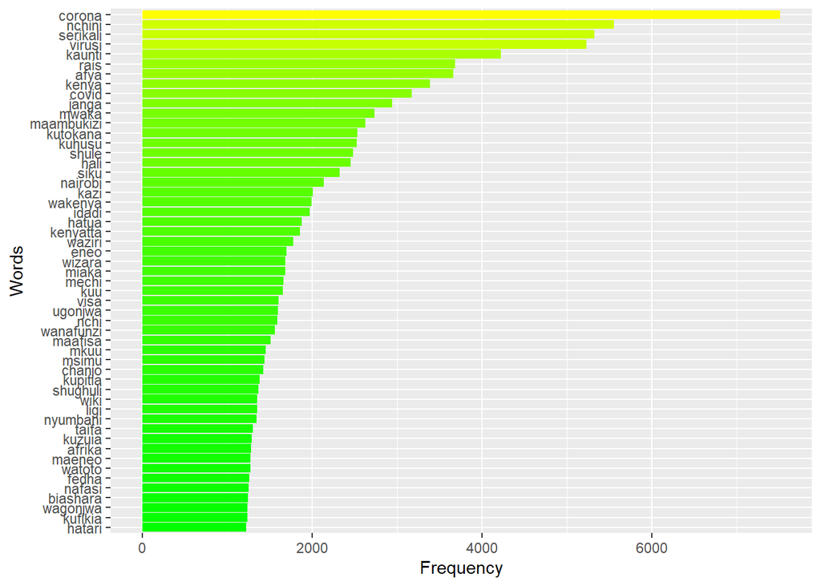

```r
new_txtdata %>% count(word) %>% filter(n > 1200) %>% ggplot(aes(
  x = reorder(word, n),
  y = n,
  fill = n
)) + geom_col() + coord_flip() + theme(legend.position = "none") + scale_fill_gradient(low = "green",
                                                                                       high = "yellow",
                                                                                       na.value = NA) +
  labs(x = "Words",
       y = "Frequency")
```

**Visualizing word frequencies in word cloud**

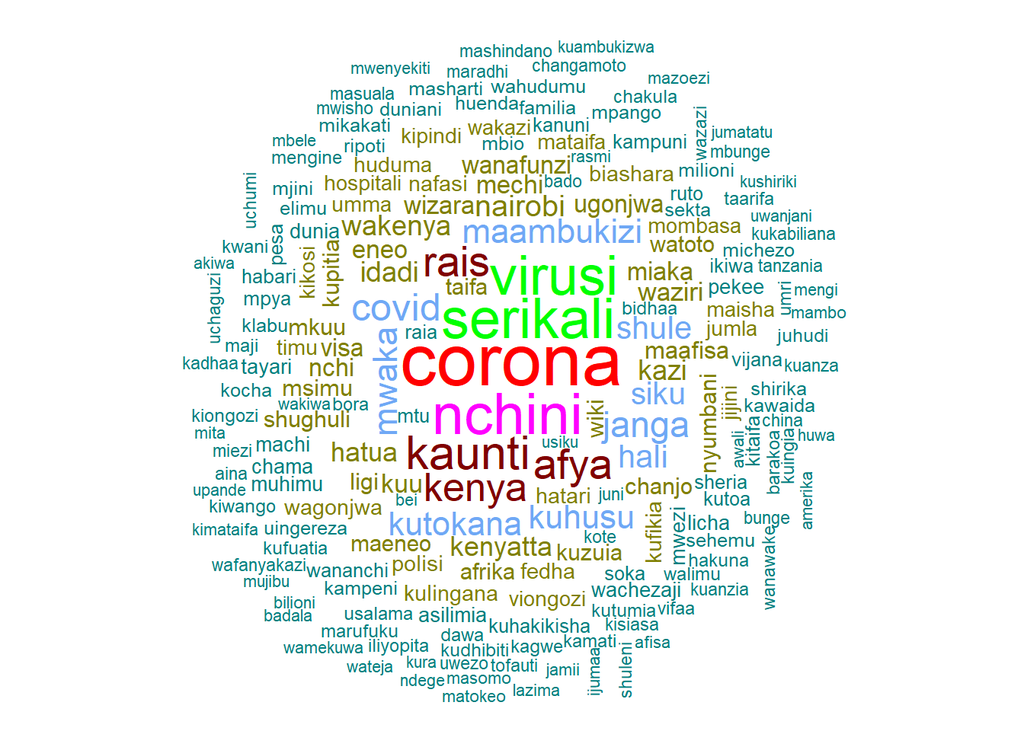

```r
word_frequencies <- new_txtdata %>% count(word)

wordcloud(
  words = word_frequencies$word,
  freq = word_frequencies$n,
  random.order = FALSE,
  scale = c(3, 0.5),
  min.freq = 1,
  max.words = 200,
  colors = c("#008080","#808000", "#6FA8F5", "#800000", "#00FF00", "#FF00FF", "#FF0000")
)
```

### N-grams to exploring correlations of words

**Create bigrams**

```r
nw_df <- df %>%
  unnest_tokens(bigram, Content, token = "ngrams", n = 2) %>%
  select(bigram)
```

**Remove rows containing numbers**

```r
nw_txtdata <-
  nw_df %>% slice(which(!grepl("[[:digit:]]", bigram)))
```

**Inspect frequency of bigrams**

```r
nw_txtdata %>% count(bigram, sort = TRUE)
```

```
## # A tibble: 464,678 × 2
##    bigram          n
##    <chr>       <int>
##  1 baada ya     5028
##  2 vya corona   3748
##  3 virusi vya   3597
##  4 kutokana na  2499
##  5 janga la     2196
##  6 kaunti ya    1880
##  7 kati ya      1788
##  8 baadhi ya    1663
##  9 kabla ya     1648
## 10 zaidi ya     1613
## # … with 464,668 more rows
```

**Split the bigram**

```r
bigram_split <- nw_txtdata %>%
  separate(col = bigram,
           into = c("word1", "word2"),
           sep = " ")
```

**Retain values in word1 and word2 that are not a word in stop_words**

```r
bigram_cleaned <-
  bigram_split %>%
  filter(!word1 %in% stp_words$word) %>%
  filter(!word2 %in% stp_words$word)

bigram_cleaned <- bigram_cleaned %>%
  count(word1, word2, sort = TRUE)
```

**Join words for plotting**

```r
bigram_cleaned %>%
  unite(col = bigram,
        word1, word2,
        sep = " ")
```

```
## # A tibble: 223,857 × 2
##    bigram                n
##    <chr>             <int>
##  1 rais kenyatta       889
##  2 ligi kuu            801
##  3 jijini nairobi      436
##  4 nchini kenya        312
##  5 kuzuia maambukizi   307
##  6 chuo kikuu          303
##  7 kote nchini         299
##  8 corona nchini       250
##  9 afrika kusini       241
## 10 wiki iliyopita      236
## # … with 223,847 more rows
```

**Make plot reproducible**

```r
set.seed(1234)
```

**Create the special igraph object**

```r
graph <- igraph::graph_from_data_frame(bigram_cleaned)
```

**Filter the bigram for values more than 60**

```r
network_plot <- bigram_cleaned %>%
  filter(n > 60) %>%
  igraph::graph_from_data_frame()
```

**Plot network plot**

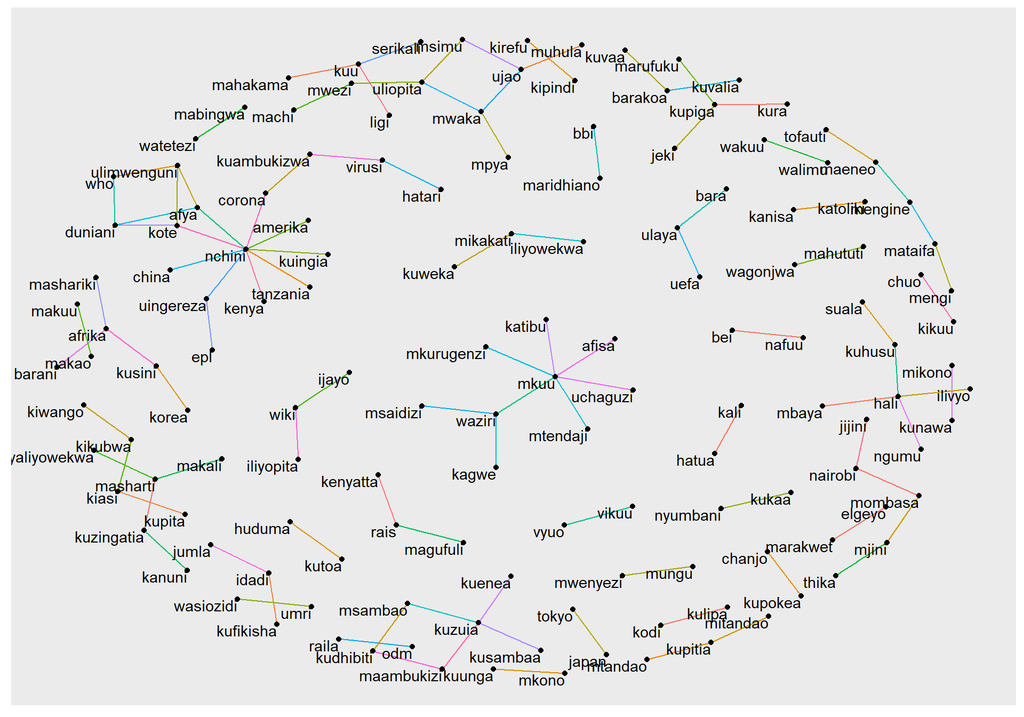

```r
network_plot %>%
  ggraph(layout = 'kk') +
  geom_edge_link(aes(col = factor(n)), show.legend = FALSE) +
  geom_node_point() +
  geom_node_text(aes(label = name),
                 vjust = 1,
                 hjust = 1)
```

## References

Masua, Bernard, and Noel Masasi. 2020. “Enhancing Text Pre-Processing for Swahili Language: Datasets for Common Swahili Stop-Words, Slangs and Typos with Equivalent Proper Words.” *Data in Brief* 33 (December): 106517. https://doi.org/10.1016/j.dib.2020.106517.

Robertson, Stephen. 2004. “Understanding Inverse Document Frequency: On Theoretical Arguments for IDF.” *Journal of Documentation*.